# COVID-19 Crisis

The world is still struggling with one of the most rapidly spreading pandemics. There are a lot of people who say that data is the best weapon we can use in this "Corona Fight."

Imagine that you are one of the best data scientists in your country. The president of your country asked you to analyze the COVID-19 patient-level data of South Korea and prepare your homeland for the next wave of the pandemic. You, as the lead data scientist of your country have to create and prove a plan of fighting the pandemics in your country by analyzing the [provided data](https://www.kaggle.com/kimjihoo/coronavirusdataset/). You must get the most critical insights using learned data science techniques and present them to the lead of your country.

## Background

### Requirements

- Perform data cleaning and feature engineering. Work with features - handle missing data if needed, use Pandas date APIs, create other additional features.
- Perform exploratory data analysis. Describe the data with basic statistical parameters - mean, median, quantiles, etc. Use parameters that give you the most important statistical insights of the data. Grouping the data and analyzing the groups - using Pandas aggregate methods. Visualize the data - you can use line, scatter, histogram plots, density plots, regplots, etc.
- Provide clear explanations in your notebook. Your explanations should inform the reader what you are trying to achieve, what results did you get, and what these results mean.
- Present the project - the data, methods, and results.
- Provide suggestions about how your analysis can be improved.

### Bonus Challenges

As a data scientists you will spend significant amount of your time learning new things. Sometimes you will do that for fun, but most of the time you will have an urgent problem and you will need to quickly learn some new skill to be able to solve it. It is very important to gradually build this skill - it is extremely valuable for all data scientists. The bonus challenges are designed to simulate these types of situations. These challenges require you to do something that we haven't covered in the course yet. Instead of trying to do all of the bonus challenges, concentrate on just one or two and do them well. All of the bonus challenges are optional - no points will be deducted if you skip them.

- Try dimensionality reduction algorithm (e.g. PCA, t-SNE, Autoencoder).
- Try clustering your data.
- Try a machine learning model to explain relationships between features and predict new values.
- Try to use a statistical significance test.

## Preparation

```python
import pandas as pd
import numpy as np
import matplotlib.pyplot as plt
import matplotlib.animation as animation
import seaborn as sns
from sklearn.preprocessing import StandardScaler
from sklearn.cluster import KMeans
from kneed import KneeLocator
import geopandas as gpd
from shapely.geometry import Point, Polygon
from sklearn.cluster import KMeans
import warnings
from pandas.core.common import SettingWithCopyWarning
sns.set(rc={'figure.figsize':( 15, 15)})
```

```python
warnings.simplefilter(action="ignore", category=SettingWithCopyWarning)
```

```python
cases = pd.read_csv(r'Case.csv', index_col=0)                    # Data of COVID-19 infection cases in South Korea
patient_info = pd.read_csv(r'PatientInfo.csv', index_col=0)      # Epidemiological data of COVID-19 patients in South Korea
policy = pd.read_csv(r'Policy.csv', index_col=0)                 # Data of the government policy for COVID-19 in South Korea
region = pd.read_csv(r'Region.csv', index_col=0)                 # Location and statistical data of the regions in South Korea
search_trend = pd.read_csv(r'SearchTrend.csv', index_col=0)      # Trend data of the keywords searched in NAVER which is one of the largest portals in South Korea
time = pd.read_csv(r'Time.csv', index_col=0)                     # Time series data of COVID-19 status in South Korea
time_age = pd.read_csv(r'TimeAge.csv', index_col=0)              # Time series data of COVID-19 status in terms of the age in South Korea
time_gender = pd.read_csv(r'TimeGender.csv', index_col=0)        # Time series data of COVID-19 status in terms of gender in South Korea
time_province = pd.read_csv(r'TimeProvince.csv', index_col=0)    # Time series data of COVID-19 status in terms of the Province in South Korea
weather = pd.read_csv(r'Weather.csv', index_col=0)               # Data of the weather in the regions of South Korea
```

```python
# COVID-19 Dataset
country_wise_latest = pd.read_csv(r'country_wise_latest.csv')
```

## Cleaning

All given datasets were chechked for NaNs: `x_dataset.isnull().sum()`. Most of them did not include NaNs.

```python
patient_info.isnull().sum()
```

```
sex                   1122
age                   1380
country                  0
province                 0
city                    94
infection_case         919
infected_by           3819
contact_number        4374
symptom_onset_date    4475
confirmed_date           3
released_date         3578
deceased_date         5099
state                    0
dtype: int64
```

```python
patient_info.info()
```

```
<class 'pandas.core.frame.DataFrame'>
Int64Index: 5165 entries, 1000000001 to 7000000019
Data columns (total 13 columns):
 #   Column              Non-Null Count  Dtype
---  ------              --------------  -----
 0   sex                 4043 non-null   object
 1   age                 3785 non-null   object
 2   country             5165 non-null   object
 3   province            5165 non-null   object
 4   city                5071 non-null   object
 5   infection_case      4246 non-null   object
 6   infected_by         1346 non-null   object
 7   contact_number      791 non-null    object
 8   symptom_onset_date  690 non-null    object
 9   confirmed_date      5162 non-null   object
 10  released_date       1587 non-null   object
 11  deceased_date       66 non-null     object
 12  state               5165 non-null   object
dtypes: object(13)
memory usage: 564.9+ KB
```

Not to lose important data in `Patient_info` dataset, I am going to replace NaNs.

`Patient_info` columns 'sex', 'age', 'city', 'infected_by' NaNs are going to be replaced:

**/ The 'infected_by' includes keys. The first one starts from 1000000001. The missing values can be replaced by 0000000000 then. It is going to help with clustering in the following steps and the data is not going to be disorted.

```python
patient_info['sex'].fillna('', inplace = True)
patient_info['age'].fillna('No Info', inplace = True)
patient_info['city'].fillna('No Info', inplace = True)
patient_info['infected_by'].fillna('0000000000', inplace = True)
patient_info['contact_number'].fillna(np.NaN, inplace = True)
```

The 'contact_number' column values are the object datatype. To change NaNs to 'contact_number' mean, the following steps has to be done:

```python
patient_info['contact_number'].str.contains('-').sum()
```

```
4
```

```python
patient_info['contact_number'] = patient_info['contact_number'].replace({'-': np.NaN})
```

```python
patient_info['contact_number'].str.contains('-').sum()
```

```
0
```

A short explanation: the 'contact_number' cleaning lead to '-' character detection. I replaced them by NaNs. Then, to keep data undistorted, I could not change NaNs by zeros. The zeros are present in this column, thus it means, that the patient knew that there was no contact with him/her. I came to conclusion to change NaNs by negative number because patient can not have a negative number of contacts. Then I can easily change object datatype to numeric. After that negative values change to 'contact_number' median. I chose median because one outlier disturbed the value of the mean and it was not representing data correctfully.

```python
patient_info['contact_number'].fillna('-1', inplace = True)
```

```python
patient_info['contact_number'] = patient_info['contact_number'].astype(float)
```

```python
patient_info['contact_number'] = patient_info['contact_number'].replace({-1: np.NaN})
```

```python
patient_info['contact_number'].fillna(value = patient_info['contact_number'].median(), inplace=True)
patient_info.tail()
```

| patient_id | sex | age | country | province | city | infection_case | infected_by | contact_number | symptom_onset_date | confirmed_date | released_date | deceased_date | state |
| --- | --- | --- | --- | --- | --- | --- | --- | --- | --- | --- | --- | --- | --- |
| 7000000015 | female | 30s | Korea | Jeju-do | Jeju-do | overseas inflow | 0000000000 | 25.0 | NaN | 2020-05-30 | 2020-06-13 | NaN | released |
| 7000000016 |  | No Info | Korea | Jeju-do | Jeju-do | overseas inflow | 0000000000 | 4.0 | NaN | 2020-06-16 | 2020-06-24 | NaN | released |
| 7000000017 |  | No Info | Bangladesh | Jeju-do | Jeju-do | overseas inflow | 0000000000 | 72.0 | NaN | 2020-06-18 | NaN | NaN | isolated |
| 7000000018 |  | No Info | Bangladesh | Jeju-do | Jeju-do | overseas inflow | 0000000000 | 4.0 | NaN | 2020-06-18 | NaN | NaN | isolated |
| 7000000019 |  | No Info | Bangladesh | Jeju-do | Jeju-do | overseas inflow | 0000000000 | 4.0 | NaN | 2020-06-18 | NaN | NaN | isolated |

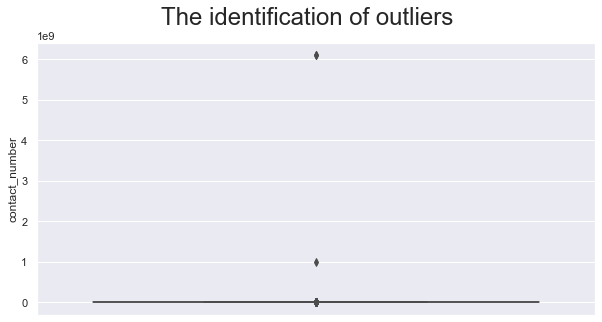

```python
fig, axes = plt.subplots(figsize=(10, 5))
fig.suptitle("The identification of outliers", fontsize = 24)
sns.boxplot(data = patient_info, y = patient_info['contact_number']);
```

```python
patient_info.shape
```

```
(5165, 13)
```

```python
q75,q25 = np.percentile(patient_info.loc[:, 'contact_number'],[99, 1])
intr_qr = q75 - q25

max = q75+(1.5*intr_qr)
min = q25-(1.5*intr_qr)

patient_info.loc[patient_info['contact_number'] < min, 'contact_number'] = np.nan
patient_info.loc[patient_info['contact_number'] > max, 'contact_number'] = np.nan
```

```python
patient_info.isnull().sum()
```

```
sex                      0
age                      0
country                  0
province                 0
city                     0
infection_case         919
infected_by              0
contact_number          22
symptom_onset_date    4475
confirmed_date           3
released_date         3578
deceased_date         5099
state                    0
dtype: int64
```

```python
patient_info['contact_number'].fillna(value = patient_info['contact_number'].mean(), inplace=True)
```

```python
patient_info.tail()
```

| patient_id | sex | age | country | province | city | infection_case | infected_by | contact_number | symptom_onset_date | confirmed_date | released_date | deceased_date | state |
| --- | --- | --- | --- | --- | --- | --- | --- | --- | --- | --- | --- | --- | --- |
| 7000000015 | female | 30s | Korea | Jeju-do | Jeju-do | overseas inflow | 0000000000 | 25.0 | NaN | 2020-05-30 | 2020-06-13 | NaN | released |
| 7000000016 |  | No Info | Korea | Jeju-do | Jeju-do | overseas inflow | 0000000000 | 4.0 | NaN | 2020-06-16 | 2020-06-24 | NaN | released |
| 7000000017 |  | No Info | Bangladesh | Jeju-do | Jeju-do | overseas inflow | 0000000000 | 72.0 | NaN | 2020-06-18 | NaN | NaN | isolated |
| 7000000018 |  | No Info | Bangladesh | Jeju-do | Jeju-do | overseas inflow | 0000000000 | 4.0 | NaN | 2020-06-18 | NaN | NaN | isolated |
| 7000000019 |  | No Info | Bangladesh | Jeju-do | Jeju-do | overseas inflow | 0000000000 | 4.0 | NaN | 2020-06-18 | NaN | NaN | isolated |

```python
patient_info['infected_by'] = patient_info['infected_by'].replace({'1500000050, 1500000055': '1500000050'})
```

Here I replaced two cases numbers by one, just to properly use the dataframe for clustering, plotting and etc.

`patient_info` is tidied.

## EDA

Here I am going to use [Geopandas](https://geopandas.org/index.html) package for plotting the data distrivution via country maps.

This project is perfect for data visualization via maps. The inspiration was taken from this [article](https://ourworldindata.org/covid-exemplar-south-korea). Here it beautifully tells the story and how each action made an impact to South Korea COVID-19 pandemic situation.

The following EDA is my implementation of this particular dataset.

## COVID-19 Situation Worldwide:

Here I am using shapely files for visualisation of world map.

The explanation of the following steps:

Since the .shp file includes only the data of countries map, location and etc., it has to be combined with the data that shows some kind of information for that specific country, e.g. how many COVID-19 cases are in the country?

Basically, I am trying to combine two different datasets by the country name and visualize it.

```python
gdf = gpd.read_file('geometry_info/99bfd9e7-bb42-4728-87b5-07f8c8ac631c2020328-1-1vef4ev.lu5nk.shp')
gdf.head()
```

|  | OBJECTID | CNTRY_NAME | geometry |
| --- | --- | --- | --- |
| 0 | 1 | Aruba | POLYGON ((-69.88223 12.41111, -69.94695 12.436... |
| 1 | 2 | Antigua and Barbuda | MULTIPOLYGON (((-61.73889 17.54055, -61.75195 ... |
| 2 | 3 | Afghanistan | POLYGON ((61.27656 35.60725, 61.29638 35.62853... |
| 3 | 4 | Algeria | POLYGON ((-5.15213 30.18047, -5.13917 30.19236... |
| 4 | 5 | Azerbaijan | MULTIPOLYGON (((45.02583 41.03055, 45.00999 41... |

```python
gdf.dtypes
```

```
OBJECTID         int64
CNTRY_NAME      object
geometry      geometry
dtype: object
```

```python
country_wise_latest.head()
```

|  | Country/Region | Confirmed | Deaths | Recovered | Active | New cases | New deaths | New recovered | Deaths / 100 Cases | Recovered / 100 Cases | Deaths / 100 Recovered | Confirmed last week | 1 week change | 1 week % increase | WHO Region |
| --- | --- | --- | --- | --- | --- | --- | --- | --- | --- | --- | --- | --- | --- | --- | --- |
| 0 | Afghanistan | 36263 | 1269 | 25198 | 9796 | 106 | 10 | 18 | 3.50 | 69.49 | 5.04 | 35526 | 737 | 2.07 | Eastern Mediterranean |
| 1 | Albania | 4880 | 144 | 2745 | 1991 | 117 | 6 | 63 | 2.95 | 56.25 | 5.25 | 4171 | 709 | 17.00 | Europe |
| 2 | Algeria | 27973 | 1163 | 18837 | 7973 | 616 | 8 | 749 | 4.16 | 67.34 | 6.17 | 23691 | 4282 | 18.07 | Africa |
| 3 | Andorra | 907 | 52 | 803 | 52 | 10 | 0 | 0 | 5.73 | 88.53 | 6.48 | 884 | 23 | 2.60 | Europe |
| 4 | Angola | 950 | 41 | 242 | 667 | 18 | 1 | 0 | 4.32 | 25.47 | 16.94 | 749 | 201 | 26.84 | Africa |

```python
country_wise_latest.groupby('Country/Region').mean()['Confirmed'].sort_values(ascending=False)
```

```
Country/Region
US                       4290259.0
Brazil                   2442375.0
India                    1480073.0
Russia                    816680.0
South Africa              452529.0
                           ...
Dominica                      18.0
Saint Kitts and Nevis         17.0
Greenland                     14.0
Holy See                      12.0
Western Sahara                10.0
Name: Confirmed, Length: 187, dtype: float64
```

```python
country_wise_latest[(country_wise_latest['Country/Region'] == 'US')]
```

|  | Country/Region | Confirmed | Deaths | Recovered | Active | New cases | New deaths | New recovered | Deaths / 100 Cases | Recovered / 100 Cases | Deaths / 100 Recovered | Confirmed last week | 1 week change | 1 week % increase | WHO Region |
| --- | --- | --- | --- | --- | --- | --- | --- | --- | --- | --- | --- | --- | --- | --- | --- |
| 173 | US | 4290259 | 148011 | 1325804 | 2816444 | 56336 | 1076 | 27941 | 3.45 | 30.9 | 11.16 | 3834677 | 455582 | 11.88 | Americas |

```python
country_wise_latest.at[173, 'Country/Region'] = 'United States'
```

```python
gdf.columns = ['OBJECTID', 'Country/Region', 'geometry']
```

```python
all_countries = gdf['Country/Region'].to_list()
```

```python
data_glob = gdf[gdf['Country/Region'].isin(country_wise_latest['Country/Region'].to_list())]
```

```python
country_wise_latest_df = country_wise_latest.merge(data_glob, on='Country/Region')
country_wise_latest_df.shape
```

```
(166, 17)
```

```python
others = gdf[~gdf['Country/Region'].isin(country_wise_latest['Country/Region'].to_list())]
```

```python
others['Confirmed'] = np.NaN
```

```python
country_wise_latest_geo = pd.concat([country_wise_latest_df, others])
```

```python
country_wise_latest_geo.isnull().sum()
```

```
Country/Region             0
Confirmed                 85
Deaths                    85
Recovered                 85
Active                    85
New cases                 85
New deaths                85
New recovered             85
Deaths / 100 Cases        85
Recovered / 100 Cases     85
Deaths / 100 Recovered    85
Confirmed last week       85
1 week change             85
1 week % increase         85
WHO Region                85
OBJECTID                   0
geometry                   0
dtype: int64
```

```python
type(country_wise_latest_geo)
```

```
pandas.core.frame.DataFrame
```

```python
country_wise_latest_geo = gpd.GeoDataFrame(country_wise_latest_geo)
```

```python
type(country_wise_latest_geo)
```

```
geopandas.geodataframe.GeoDataFrame
```

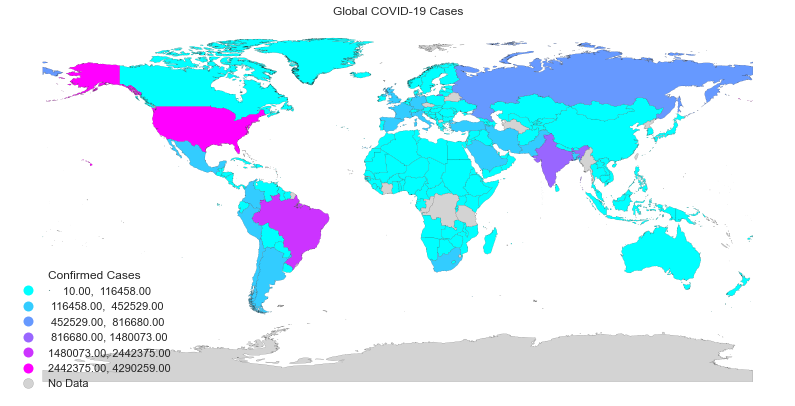

```python
fig, ax = plt.subplots(figsize=(14, 14))

country_wise_latest_geo.plot(ax=ax, figsize=(14, 16), column=country_wise_latest_geo['Confirmed'], cmap='cool', k=6,
            missing_kwds=dict(color="lightgrey",label='No Data'),
            scheme='FisherJenks',
            edgecolor = 'black',
            legend=True,
            linewidth = 0.1,
            legend_kwds=dict(loc='lower left', frameon=False, title='Confirmed Cases'))

ax.set(title='Global COVID-19 Cases')
ax.set_axis_off()


plt.show()
```

Here we can see that purple countries has the most cases of COVID-19. The top three is:

- USA
- Brazil
- India

However, there are some countries that are considered as an example of handling the pandemic. One of these countries are South Korea. [In this article](https://ourworldindata.org/covid-exemplar-south-korea) it is beautifully explained how South Korea has handled this critical situation.

## South Korea Situation During COVID-19 Pandemic

South Korea's population was [51,269,185](https://www.worldometers.info/world-population/south-korea-population/) at 2020.

Let's see how the COVID-19 cases has distributed across the country:

```python
cases.head()
```

| case_id | province | city | group | infection_case | confirmed | latitude | longitude |
| --- | --- | --- | --- | --- | --- | --- | --- |
| 1000001 | Seoul | Yongsan-gu | True | Itaewon Clubs | 139 | 37.538621 | 126.992652 |
| 1000002 | Seoul | Gwanak-gu | True | Richway | 119 | 37.48208 | 126.901384 |
| 1000003 | Seoul | Guro-gu | True | Guro-gu Call Center | 95 | 37.508163 | 126.884387 |
| 1000004 | Seoul | Yangcheon-gu | True | Yangcheon Table Tennis Club | 43 | 37.546061 | 126.874209 |
| 1000005 | Seoul | Dobong-gu | True | Day Care Center | 43 | 37.679422 | 127.044374 |

```python
cases['latitude'].str.contains('-').sum()
```

```
109
```

```python
cases['latitude'] = cases['latitude'].replace({'-': np.NaN})
cases['longitude'] = cases['longitude'].replace({'-': np.NaN})
```

```python
cases.isnull().sum()
```

```
province            0
city                0
group               0
infection_case      0
confirmed           0
latitude          109
longitude         109
dtype: int64
```

```python
cases['latitude'] = cases['latitude'].dropna()
cases['longitude'] = cases['longitude'].dropna()
```

```python
cases['latitude'] = cases['latitude'].astype(float)
```

```python
cases['longitude'] = cases['longitude'].astype(float)
```

Here I cleaned the `cases` dataset for adding new feature: geometry. This will help to plot the map of South Korea and to link the map with needed information.

```python
crs = {'init' : 'epsg:4326'}
```

```python
geometry = [Point (xy) for xy in zip( cases['longitude'], cases['latitude'])]
geometry[:3]
```

```
[<shapely.geometry.point.Point at 0x1f26a2570d0>,
 <shapely.geometry.point.Point at 0x1f26a257520>,
 <shapely.geometry.point.Point at 0x1f26a257670>]
```

```python
geo_df_sk = gpd.GeoDataFrame(cases,
                             crs = crs,
                             geometry = geometry)
geo_df_sk.head()
```

| case_id | province | city | group | infection_case | confirmed | latitude | longitude | geometry |
| --- | --- | --- | --- | --- | --- | --- | --- | --- |
| 1000001 | Seoul | Yongsan-gu | True | Itaewon Clubs | 139 | 37.538621 | 126.992652 | POINT (126.99265 37.53862) |
| 1000002 | Seoul | Gwanak-gu | True | Richway | 119 | 37.482080 | 126.901384 | POINT (126.90138 37.48208) |
| 1000003 | Seoul | Guro-gu | True | Guro-gu Call Center | 95 | 37.508163 | 126.884387 | POINT (126.88439 37.50816) |
| 1000004 | Seoul | Yangcheon-gu | True | Yangcheon Table Tennis Club | 43 | 37.546061 | 126.874209 | POINT (126.87421 37.54606) |
| 1000005 | Seoul | Dobong-gu | True | Day Care Center | 43 | 37.679422 | 127.044374 | POINT (127.04437 37.67942) |

```python
sk_map = gpd.read_file('geometry_info/South_Korea/south_korea_administrative_outline_boundary.shp')
```

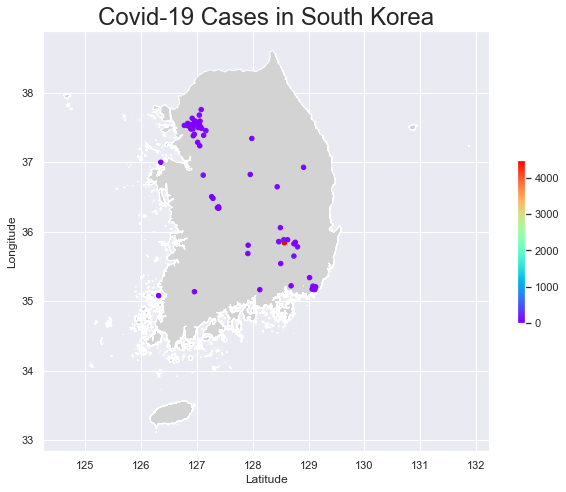

```python
fig, ax = plt.subplots(figsize = (10,10))
sk_map.to_crs(epsg=4326).plot(ax=ax, color='lightgrey')
geo_df_sk.plot(column = 'confirmed', ax=ax, cmap = 'rainbow',
            legend = True, legend_kwds={'shrink': 0.3},
            markersize = 20)
ax.set_title('Covid-19 Cases in South Korea', fontsize = 24)
ax.set_xlabel('Latitude')
ax.set_ylabel('Longitude');
```

This map of South Korea shows the coordinates of places where are the most cases of COVID-19. Still it is not enough information since we do not know in which exact city the clusters of COVID-19 cases are. The following interactive map shows the exact location of each case and shows more insightful information.

Here we can see that the most affected cities are Seoul, Daegu and Pusan. To add more, in the **K-Means Clustering** section, I have done clustering which complements these two South Korea maps.

```python
import folium
southkorea_map = folium.Map(location=[36.55,126.983333 ], zoom_start=7,tiles='Stamen Toner')

for lat, lon,city in zip(region['latitude'], region['longitude'], region['city']):
    folium.CircleMarker([lat, lon],
                        radius=2,
                        color='blue',
                      popup =('City: ' + str(city) + '<br>'),
                        fill_color='blue',
                        fill_opacity=0.2 ).add_to(southkorea_map)
southkorea_map
```

[interactive chart not shown]

Let's take a look how COVID-19 has done impact for each age category.

We will start from contact number and age group dependency.

```python
patient_info = patient_info.sort_values('age',ascending = True)
patient_info.tail(2)
```

| patient_id | sex | age | country | province | city | infection_case | infected_by | contact_number | symptom_onset_date | confirmed_date | released_date | deceased_date | state |
| --- | --- | --- | --- | --- | --- | --- | --- | --- | --- | --- | --- | --- | --- |
| 1000001071 |  | No Info | Korea | Seoul | Gangdong-gu | overseas inflow | 0000000000 | 4.0 | NaN | 2020-06-11 | NaN | NaN | isolated |
| 7000000019 |  | No Info | Bangladesh | Jeju-do | Jeju-do | overseas inflow | 0000000000 | 4.0 | NaN | 2020-06-18 | NaN | NaN | isolated |

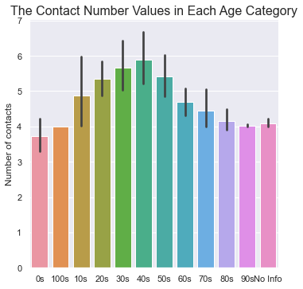

```python
q = sns.catplot(x = 'age', y = 'contact_number', data = patient_info, height = 5, kind = 'bar')
plt.title("The Contact Number Values in Each Age Category", fontsize = 16)
q.set_axis_labels("", "Number of contacts");
```

Here we can see that people in the 40s has the most contact with other people. It can be explained that South Korea's average person age of working class is [42.9](https://www.statista.com/statistics/641956/south-korea-average-age-employees/) years. People have to go to work and they do not avoid the contacts with other people

```python
patient_info['age'] = patient_info['age'].str[:-1]
```

```python
patient_info['age'] = patient_info['age'].replace({'No Inf': "43.7"})
```

```python
patient_info['age'] = patient_info['age'].astype(float)
```

```python
patient_info.head(2)
```

| patient_id | sex | age | country | province | city | infection_case | infected_by | contact_number | symptom_onset_date | confirmed_date | released_date | deceased_date | state |
| --- | --- | --- | --- | --- | --- | --- | --- | --- | --- | --- | --- | --- | --- |
| 1100000126 | male | 0.0 | Korea | Busan | Dongnae-gu | overseas inflow | 0000000000 | 3.0 | NaN | 2020-04-15 | NaN | NaN | isolated |
| 4100000096 | female | 0.0 | Korea | Chungcheongnam-do | Cheonan-si | contact with patient | 4100000094 | 0.0 | NaN | 2020-03-07 | 2020-03-28 | NaN | released |

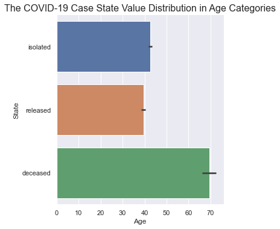

```python
q = sns.catplot(x = 'age', y = 'state', data = patient_info, height = 5, kind = 'bar')
q.set_axis_labels("Age", "State");
plt.title('The COVID-19 Case State Value Distribution in Age Categories', fontsize = 16);
```

This graph shows that COVID-19 virus is dangerous for each age group, especially for elders: the isolated and released bars do not reach above 50 years old boundary.

```python
time_age.head()
```

| date | time | age | confirmed | deceased |
| --- | --- | --- | --- | --- |
| 2020-03-02 | 0 | 0s | 32 | 0 |
| 2020-03-02 | 0 | 10s | 169 | 0 |
| 2020-03-02 | 0 | 20s | 1235 | 0 |
| 2020-03-02 | 0 | 30s | 506 | 1 |
| 2020-03-02 | 0 | 40s | 633 | 1 |

```python
time_age = time_age.reset_index()
time_age.info()
```

```
<class 'pandas.core.frame.DataFrame'>
RangeIndex: 1089 entries, 0 to 1088
Data columns (total 5 columns):
 #   Column     Non-Null Count  Dtype
---  ------     --------------  -----
 0   date       1089 non-null   object
 1   time       1089 non-null   int64
 2   age        1089 non-null   object
 3   confirmed  1089 non-null   int64
 4   deceased   1089 non-null   int64
dtypes: int64(3), object(2)
memory usage: 42.7+ KB
```

```python
time_age['date'] = pd.to_datetime(time_age['date'], format = '%Y-%m-%d')
```

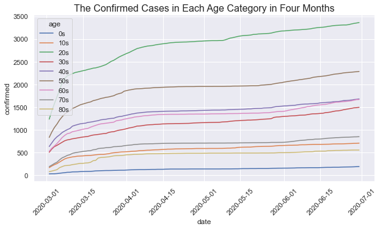

```python
plt.figure(figsize = (10, 5))
ax = sns.lineplot(data = time_age, x="date", y="confirmed",
             hue = "age")
locs, labels = plt.xticks()
plt.title('The Confirmed Cases in Each Age Category in Four Months', fontsize = 16)
plt.setp(labels, rotation=45);
```

In the four month period we can see that 20s and 50s age categories has the most cases of COVID-19. The least affected age group is 0s. This can be explained by [Nature article](https://www.nature.com/articles/s41591-020-0962-9#Abs1) that children have lower susceptibility to COVID-19.

The following steps are going to focus on comparision of two datasets in confirmed cases. Here I am going to merge the datasets and use the created merged dataframe for plotting data.

```python
time_province.head()
```

| date | time | province | confirmed | released | deceased |
| --- | --- | --- | --- | --- | --- |
| 2020-01-20 | 16 | Seoul | 0 | 0 | 0 |
| 2020-01-20 | 16 | Busan | 0 | 0 | 0 |
| 2020-01-20 | 16 | Daegu | 0 | 0 | 0 |
| 2020-01-20 | 16 | Incheon | 1 | 0 | 0 |
| 2020-01-20 | 16 | Gwangju | 0 | 0 | 0 |

```python
time = time.reset_index()
```

```python
time_province  = time_province.reset_index()
```

```python
time['date'] = pd.to_datetime(time['date'], format = '%Y-%m-%d')
```

```python
time_province['date'] = pd.to_datetime(time_province['date'], format = '%Y-%m-%d')
```

```python
merged_time_df = pd.merge(time, time_province, on = 'date')
merged_time_df.head(2)
```

|  | date | time_x | test | negative | confirmed_x | released_x | deceased_x | time_y | province | confirmed_y | released_y | deceased_y |
| --- | --- | --- | --- | --- | --- | --- | --- | --- | --- | --- | --- | --- |
| 0 | 2020-01-20 | 16 | 1 | 0 | 1 | 0 | 0 | 16 | Seoul | 0 | 0 | 0 |
| 1 | 2020-01-20 | 16 | 1 | 0 | 1 | 0 | 0 | 16 | Busan | 0 | 0 | 0 |

```python
column_names = ['Date', 'Time_x', 'Test','Negative','Time', 'released_x', 'deceased_x', 'Time_y', 'province', 'Time Province', 'released_y', 'deceased_y']
merged_time_df.columns = column_names
```

```python
merged_time_df = merged_time_df.reset_index()
merged_time_df.info()
```

```
<class 'pandas.core.frame.DataFrame'>
RangeIndex: 2771 entries, 0 to 2770
Data columns (total 13 columns):
 #   Column         Non-Null Count  Dtype
---  ------         --------------  -----
 0   index          2771 non-null   int64
 1   Date           2771 non-null   datetime64[ns]
 2   Time_x         2771 non-null   int64
 3   Test           2771 non-null   int64
 4   Negative       2771 non-null   int64
 5   Time           2771 non-null   int64
 6   released_x     2771 non-null   int64
 7   deceased_x     2771 non-null   int64
 8   Time_y         2771 non-null   int64
 9   province       2771 non-null   object
 10  Time Province  2771 non-null   int64
 11  released_y     2771 non-null   int64
 12  deceased_y     2771 non-null   int64
dtypes: datetime64[ns](1), int64(11), object(1)
memory usage: 281.6+ KB
```

```python
mer_df_confirmed = pd.melt(merged_time_df, col_level=0, id_vars=['Date', 'province'], value_vars=['Time', 'Time Province'])
mer_df_confirmed.head(2)
```

|  | Date | province | variable | value |
| --- | --- | --- | --- | --- |
| 0 | 2020-01-20 | Seoul | Time | 1 |
| 1 | 2020-01-20 | Busan | Time | 1 |

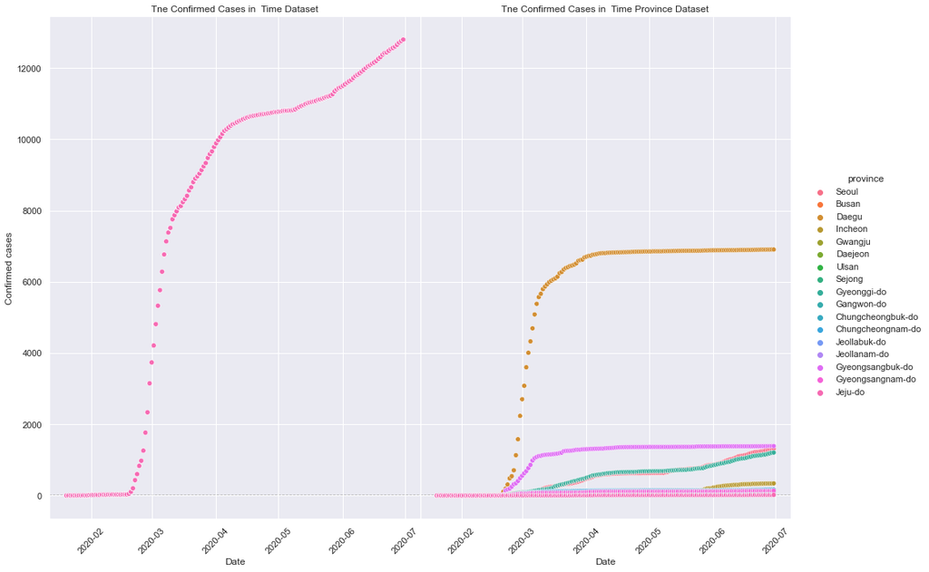

```python
g = sns.relplot(data=mer_df_confirmed, x="Date", y="value",
             col = "variable", hue = 'province',
             height=10, aspect=.7)
g.set_xticklabels(rotation=45)

(g.map(plt.axhline, y=0, color=".7", dashes=(2, 1), zorder=0)
  .set_axis_labels("Date", "Confirmed cases")
  .set_titles("Tne Confirmed Cases in  {col_name} Dataset")
  .tight_layout(w_pad=0))
plt.xticks(rotation=45);
```

Here we can see that the graph shows the confirmed cases in South Korea (the left one) and in each province. The right graph shows already seen data in the South Korea map plotting, that Daegu province has the most diffuluct COVID-19 pandemic situation. The Daegu has the first outbreak outside the China and was the unlucky one to get the [first COVID-19 case in Februrary 2020](https://catalyst.nejm.org/doi/full/10.1056/CAT.20.0159).

Does COVID-19 has the same impact for both sexes? Let's see:

```python
time_age = time_age.reset_index()
time_gender = time_gender.reset_index()
```

```python
time_age['date'] = pd.to_datetime(time_age['date'], format = '%Y-%m-%d')
```

```python
time_gender['date'] = pd.to_datetime(time_gender['date'], format = '%Y-%m-%d')
```

```python
merged_time_df2 = pd.merge(time_age, time_gender, on='date')
merged_time_df2.head()
```

|  | index | date | time_x | age | confirmed_x | deceased_x | time_y | sex | confirmed_y | deceased_y |
| --- | --- | --- | --- | --- | --- | --- | --- | --- | --- | --- |
| 0 | 0 | 2020-03-02 | 0 | 0s | 32 | 0 | 0 | male | 1591 | 13 |
| 1 | 0 | 2020-03-02 | 0 | 0s | 32 | 0 | 0 | female | 2621 | 9 |
| 2 | 1 | 2020-03-02 | 0 | 10s | 169 | 0 | 0 | male | 1591 | 13 |
| 3 | 1 | 2020-03-02 | 0 | 10s | 169 | 0 | 0 | female | 2621 | 9 |
| 4 | 2 | 2020-03-02 | 0 | 20s | 1235 | 0 | 0 | male | 1591 | 13 |

```python
mer_df2_confirmed = pd.melt(merged_time_df2, col_level=0, id_vars=['date', 'age', 'sex'], value_vars=['confirmed_x', 'confirmed_y'])
mer_df2_confirmed.head(2)
```

|  | date | age | sex | variable | value |
| --- | --- | --- | --- | --- | --- |
| 0 | 2020-03-02 | 0s | male | confirmed_x | 32 |
| 1 | 2020-03-02 | 0s | female | confirmed_x | 32 |

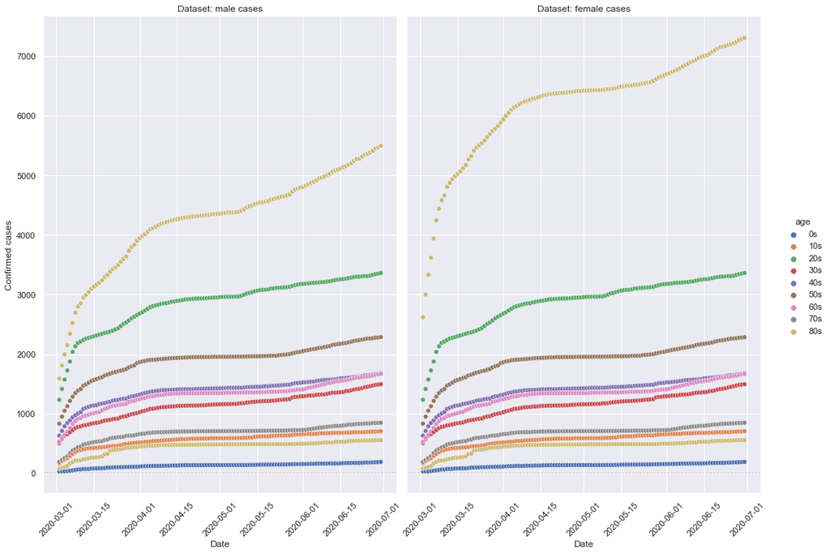

```python
g = sns.relplot(data=mer_df2_confirmed, x="date", y="value",
             col = "sex", hue = 'age',
             height=10, aspect=.7)
g.set_xticklabels(rotation=45)

(g.map(plt.axhline, y=0, color=".7", dashes=(2, 1), zorder=0)
  .set_axis_labels("Date", "Confirmed cases")
  .set_titles("Dataset: {col_name} cases")
  .tight_layout(w_pad=0))

plt.xticks(rotation=45);
```

```python
time_age = time_age.reset_index()
time_age.head(2)
```

|  | level_0 | index | date | time | age | confirmed | deceased |
| --- | --- | --- | --- | --- | --- | --- | --- |
| 0 | 0 | 0 | 2020-03-02 | 0 | 0s | 32 | 0 |
| 1 | 1 | 1 | 2020-03-02 | 0 | 10s | 169 | 0 |

```python
search_trend = search_trend.reset_index()
```

```python
start_date = '2020-01-20'
end_date = '2020-06-30'
after_start_date = search_trend["date"] >= start_date
before_end_date = search_trend['date']  <= end_date
between_two_dates = after_start_date & before_end_date
filtered_search_date = search_trend.loc[between_two_dates]
filtered_search_date.head()
```

|  | date | cold | flu | pneumonia | coronavirus |
| --- | --- | --- | --- | --- | --- |
| 1480 | 2020-01-20 | 0.19217 | 0.70343 | 3.63716 | 20.69610 |
| 1481 | 2020-01-21 | 0.22462 | 0.59789 | 4.31987 | 35.33284 |
| 1482 | 2020-01-22 | 0.23808 | 0.56661 | 3.66416 | 29.74474 |
| 1483 | 2020-01-23 | 0.30308 | 0.55625 | 3.18035 | 100.00000 |
| 1484 | 2020-01-24 | 0.34689 | 0.40226 | 2.48156 | 86.11541 |

```python
filtered_search_date['date'] = pd.to_datetime(filtered_search_date['date'], format = '%Y-%m-%d')
```

```python
search_trend_time = pd.merge(time, filtered_search_date, on = 'date')
search_trend_time.info()
```

```
<class 'pandas.core.frame.DataFrame'>
Int64Index: 162 entries, 0 to 161
Data columns (total 11 columns):
 #   Column       Non-Null Count  Dtype
---  ------       --------------  -----
 0   date         162 non-null    datetime64[ns]
 1   time         162 non-null    int64
 2   test         162 non-null    int64
 3   negative     162 non-null    int64
 4   confirmed    162 non-null    int64
 5   released     162 non-null    int64
 6   deceased     162 non-null    int64
 7   cold         162 non-null    float64
 8   flu          162 non-null    float64
 9   pneumonia    162 non-null    float64
 10  coronavirus  162 non-null    float64
dtypes: datetime64[ns](1), float64(4), int64(6)
memory usage: 15.2 KB
```

```python
search_trend_time = pd.melt(search_trend_time, id_vars=['date', 'confirmed'], value_vars=['cold', 'flu', 'pneumonia', 'coronavirus'])
search_trend_time.head(2)
```

|  | date | confirmed | variable | value |
| --- | --- | --- | --- | --- |
| 0 | 2020-01-20 | 1 | cold | 0.19217 |
| 1 | 2020-01-21 | 1 | cold | 0.22462 |

```python
column_names2 = ['date', 'confirmed', 'Search Type', 'value']
search_trend_time.columns = column_names2
```

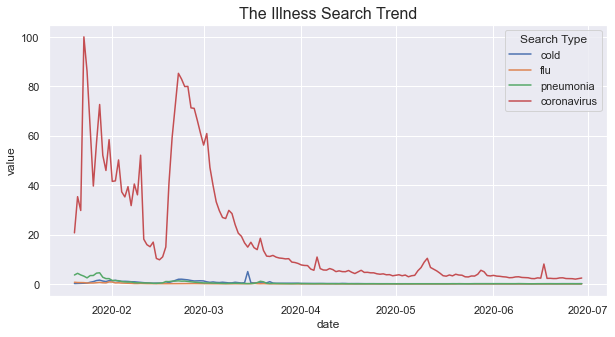

```python
plt.figure(figsize = (10, 5))
sns.lineplot(data = search_trend_time, x = 'date', y = 'value', hue = 'Search Type')
plt.title('The Illness Search Trend', fontsize = 16);
```

The Illness Search Trend graph shows that corona virus had the peak when COVID-19 started to spread in South Korea (in the beggining of the March). Before that the peaks can mean that the corona virus was searched for getting know what is happening in China.

```python
time_c_d = pd.melt(time, id_vars=['date'], value_vars=['confirmed', 'deceased'])
time_c_d.head(2)
```

|  | date | variable | value |
| --- | --- | --- | --- |
| 0 | 2020-01-20 | confirmed | 1 |
| 1 | 2020-01-21 | confirmed | 1 |

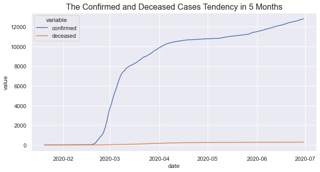

```python
plt.figure(figsize = (10, 5))
sns.lineplot(data = time_c_d, x = 'date', y = 'value', hue='variable')
plt.title('The Confirmed and Deceased Cases Tendency in 5 Months', fontsize = 16);
```

What is strange, that South Korea has quite big number of confirmed cases, but the deceased number is way lower. Why is that?

Let's see how the testing for COVID-19 was done in 5 months:

```python
time_n_p_c = pd.melt(time, id_vars=['date'], value_vars=['test', 'negative', 'confirmed'])
```

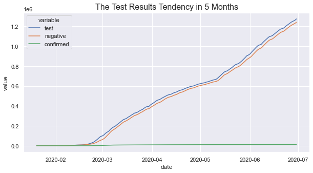

```python
plt.figure(figsize = (10, 5))
sns.lineplot(data = time_n_p_c, x = 'date', y = 'value', hue = 'variable')
plt.title('The Test Results Tendency in 5 Months', fontsize = 16);
```

This graph explains why there was such low deceased and high number of confirmed cases. The testing was one of the main reasons why South Korea was able to control COVID-19 pandemic.

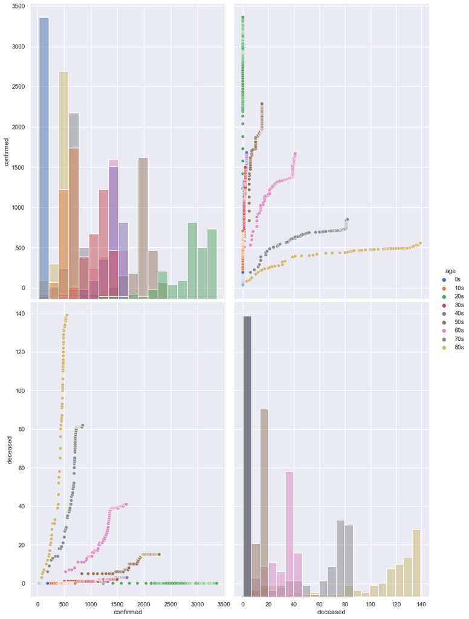

```python
sns.pairplot(time_age.iloc[:, 4:], hue="age", diag_kind="hist", height = 8, aspect =.7);
```

This graph shows the relationship between age and COVID-19 cases states. Here we can see the mentioned tendency for elders: even though the confirmed cases are lower than for example in 20s category, the number of deceased is the highest in the 80s and 70s.

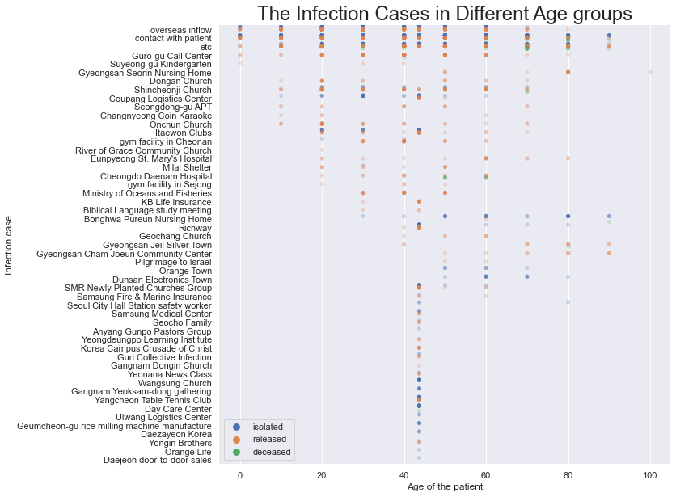

```python
figure_dim = (10, 10)
f, ax = plt.subplots(figsize=figure_dim)

sns.despine(bottom=True, left=True)

# Show each observation with a scatterplot
sns.stripplot(x="age", y="infection_case", hue = 'state',
              data=patient_info, dodge=True, alpha=.25, zorder=1).set_title("The Infection Cases in Different Age groups", fontsize = 24)
ax.set(xlabel='Age of the patient', ylabel='Infection case')
ax.legend();
```

The main reasons of getting infected are: travelling (overseas infection), contact with the patient and even going to curch.

```python
policy.head(2)
```

| policy_id | country | type | gov_policy | detail | start_date | end_date |
| --- | --- | --- | --- | --- | --- | --- |
| 1 | Korea | Alert | Infectious Disease Alert Level | Level 1 (Blue) | 2020-01-03 | 2020-01-19 |
| 2 | Korea | Alert | Infectious Disease Alert Level | Level 2 (Yellow) | 2020-01-20 | 2020-01-27 |

```python
policy = policy.reset_index()
```

```python
if ( sum(policy.index+1==policy.policy_id) == len(policy)
   ) and ( len(policy.country.unique()) == 1 ):
    policy_compact = policy.iloc[:, 2:]
print('[Sample data - compact version]')
display(policy_compact.tail(3))
```

```
[Sample data - compact version]
```

|  | type | gov_policy | detail | start_date | end_date |
| --- | --- | --- | --- | --- | --- |
| 58 | Transformation | Wearing of masks | Drivers such as buses and taxis can refuse to ... | 2020-05-26 | NaN |
| 59 | Technology | KI-Pass: Korea Internet - Pass | new quick response (QR) code system this week ... | 2020-06-10 | NaN |
| 60 | Health | Extends Tightened Quarantine Measures | Gov't Extends Tightened Quarantine Measures in... | 2020-05-28 | 2020-06-14 |

```python
policy_titles = pd.DataFrame(policy_compact.gov_policy.value_counts().items(), columns=['title', 'counts'])
policy_titles.loc[len(policy_titles), 'title'] = 'Others'
policy_titles.loc[len(policy_titles)-1, 'counts'] = policy_titles.iloc[6:, 1].sum()
policy_titles = pd.concat([policy_titles[:7], policy_titles[-1:]])
```

```python
policy_titles.head()
```

|  | title | counts |
| --- | --- | --- |
| 0 | Special Immigration Procedure | 13.0 |
| 1 | School Opening with Online Class | 10.0 |
| 2 | Emergency Use Authorization of Diagnostic Kit | 5.0 |
| 3 | Infectious Disease Alert Level | 4.0 |
| 4 | Social Distancing Campaign | 4.0 |

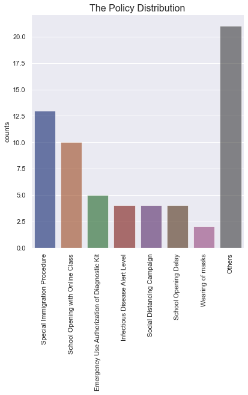

```python
sns.catplot(
    data=policy_titles, kind="bar",
    x="title", y="counts",
    ci="sd", palette="dark", alpha=.6, height=6
)
plt.title('The Policy Distribution', fontsize = 16)
plt.xlabel('')
plt.xticks(rotation=90);
```

```python
region.describe()
```

|  | latitude | longitude | elementary_school_count | kindergarten_count | university_count | academy_ratio | elderly_population_ratio | elderly_alone_ratio | nursing_home_count |
| --- | --- | --- | --- | --- | --- | --- | --- | --- | --- |
| count | 244.000000 | 244.000000 | 244.000000 | 244.000000 | 244.000000 | 244.000000 | 244.000000 | 244.000000 | 244.000000 |
| mean | 36.396996 | 127.661401 | 74.180328 | 107.901639 | 4.151639 | 1.294754 | 20.923730 | 10.644672 | 1159.258197 |
| std | 1.060304 | 0.904781 | 402.713482 | 588.788320 | 22.513041 | 0.592898 | 8.087428 | 5.604886 | 6384.185085 |
| min | 33.488936 | 126.263554 | 4.000000 | 4.000000 | 0.000000 | 0.190000 | 7.690000 | 3.300000 | 11.000000 |
| 25% | 35.405263 | 126.927663 | 14.750000 | 16.000000 | 0.000000 | 0.870000 | 14.117500 | 6.100000 | 111.000000 |
| 50% | 36.386601 | 127.384249 | 22.000000 | 31.000000 | 1.000000 | 1.270000 | 18.530000 | 8.750000 | 300.000000 |
| 75% | 37.466119 | 128.473953 | 36.250000 | 55.250000 | 3.000000 | 1.612500 | 27.262500 | 14.625000 | 694.500000 |
| max | 38.380571 | 130.905883 | 6087.000000 | 8837.000000 | 340.000000 | 4.180000 | 40.260000 | 24.700000 | 94865.000000 |

Also, the South Korea was really good prepared for pandemic situation due to previous experiences with [MERS](https://ourworldindata.org/covid-exemplar-south-korea). Here we can see that in the `region` dataset the nursing home number is quite high, which really helped to make the pandemic situation mroe controllable.

## The K-Means Clustering

As mentioned before, this section helps us to indetify how much clusters are `cases` dataset and how we can this information implement.

```python
cases.info()
```

```
<class 'pandas.core.frame.DataFrame'>
Int64Index: 174 entries, 1000001 to 7000004
Data columns (total 8 columns):
 #   Column          Non-Null Count  Dtype
---  ------          --------------  -----
 0   province        174 non-null    object
 1   city            174 non-null    object
 2   group           174 non-null    bool
 3   infection_case  174 non-null    object
 4   confirmed       174 non-null    int64
 5   latitude        65 non-null     float64
 6   longitude       65 non-null     float64
 7   geometry        174 non-null    geometry
dtypes: bool(1), float64(2), geometry(1), int64(1), object(3)
memory usage: 11.0+ KB
```

```python
cases = cases.reset_index()
```

```python
cases = cases.dropna(how = 'any')
```

```python
clus=cases.loc[:,[' case_id','latitude','longitude']]
```

```python
scaler = StandardScaler()
scaled_features = scaler.fit_transform(clus)
```

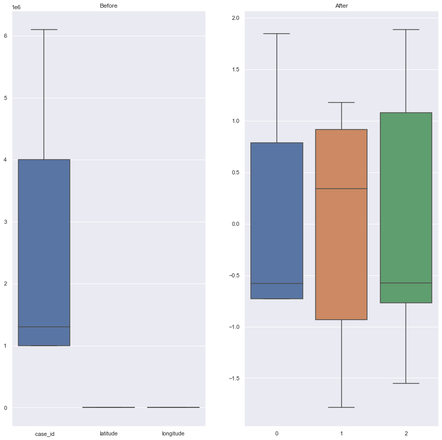

```python
fig, axs = plt.subplots(ncols=2)

sns.boxplot(data=clus, ax = axs[0])
sns.boxplot(data=scaled_features, orient='v', ax = axs[1])
axs[0].set_title('Before')
axs[1].set_title('After')

fig.set(facecolor='white')
plt.show()
```

```python
kmeans_kwargs = {
        "init": "random",
        "n_init": 10,
        "max_iter": 300,
        "random_state": 42,
    }

# A list holds the SSE values for each k
sse = []  # sum of squared error (distances in our case)
for k in range(1, 8):  # we will try clustering data into range(1, 8) clusters
  kmeans = KMeans(n_clusters=k, **kmeans_kwargs)  # initiates the k-means algorithm
  kmeans.fit(scaled_features)  # fits k-means on our scaled data
  sse.append(kmeans.inertia_)  # Sum of squared distances of samples to their closest cluster center.
```

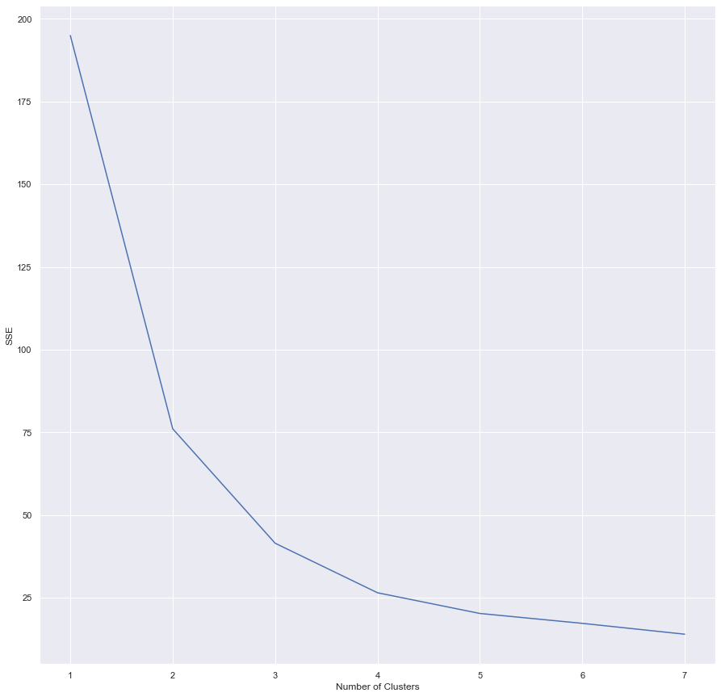

```python
fig, axs = plt.subplots()
plt.plot(range(1, 8), sse)
plt.xticks(range(1, 8))
plt.xlabel("Number of Clusters")
plt.ylabel("SSE")

fig.set(facecolor='white')
plt.show()
```

```python
kl = KneeLocator(
    range(1, 8), sse, curve="convex", direction="decreasing"
    )

print(f'You should make {kl.elbow} clusters.')
```

```
You should make 3 clusters.
```

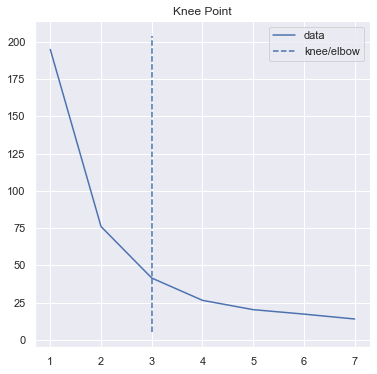

```python
kl.plot_knee()
```

```python
kmeans = KMeans(n_clusters = 3, init ='k-means++')
kmeans.fit(clus[clus.columns[1:3]])
clus['cluster_label'] = kmeans.fit_predict(clus[clus.columns[1:3]])
centers = kmeans.cluster_centers_
labels = kmeans.predict(clus[clus.columns[1:3]])
```

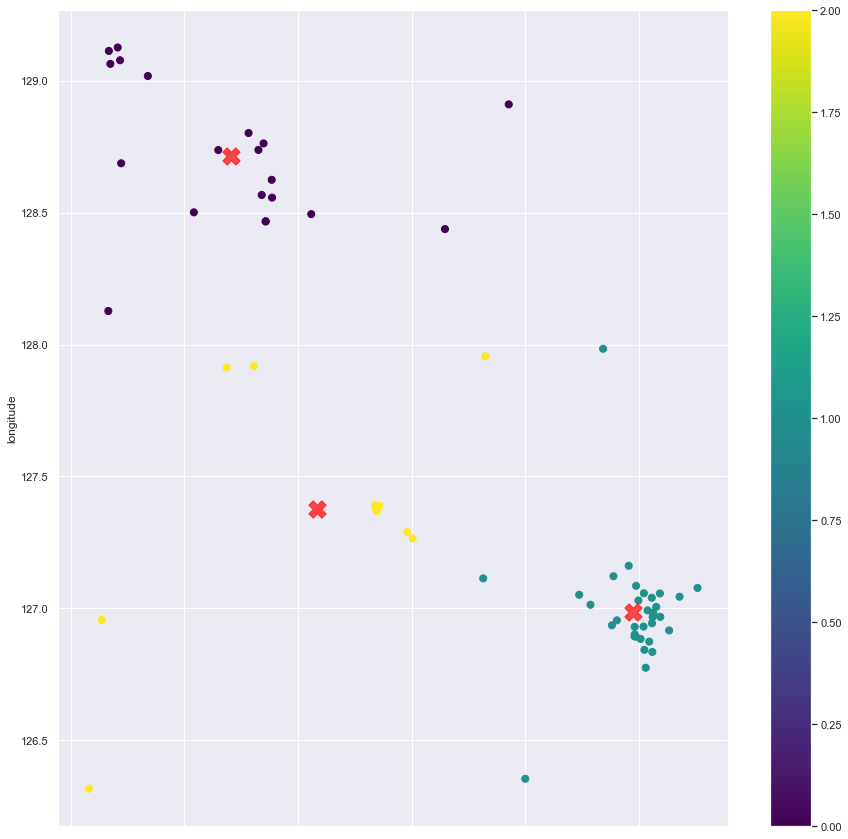

```python
clus.plot.scatter(x = 'latitude', y = 'longitude', c=labels, s=50, cmap='viridis')
plt.scatter(centers[:, 0], centers[:, 1], c='red', marker = 'X', s=300, alpha=0.7);
```

## Conclusions

These actions should be taken for stopping the pandemic in each country.

## What else could be done?

The implementation of this project could have been led into more sophisticated research:

- The COVID-19 spread prediction
- More statistical analysis how one event affect the other
- How goverment's decisions lead to COVID-19 pandemic situation control?
- Would South Korea's plan for stopping the pandemic work in other country?
- The calculations of cases each day per 10k people
- ...

...and many more questions to answer!

## Resources

- [About the dataset](https://www.cmu.edu/dietrich/causality/CameraReadys-accepted%20papers/55%5CCameraReady%5Cpaper.pdf)
- https://www.kaggle.com/imdevskp/corona-virus-report
- https://www.kaggle.com/gpreda/covid-world-vaccination-progress
- https://salernoali.medium.com/making-an-animated-graph-with-matplotlib-seaborn-3f865fa8c16a
- https://towardsdatascience.com/animations-with-matplotlib-d96375c5442c
- https://dictionary.cambridge.org/dictionary/english/floating-population
- https://machinelearningmastery.com/dimensionality-reduction-algorithms-with-python/
- https://ourworldindata.org/covid-exemplar-south-korea
- https://melaniesoek0120.medium.com/data-visualization-how-to-plot-a-map-with-geopandas-in-python-73b10dcd4b4b <- geopandas
- https://scikit-learn.org/stable/modules/clustering.html <- clustering
- https://www.cdc.gov/coronavirus/2019-ncov/symptoms-testing/symptoms.html
- https://publicholidays.co.kr/2020-dates/
- https://melaniesoek0120.medium.com/data-visualization-how-to-plot-a-map-with-geopandas-in-python-73b10dcd4b4b
- https://github.com/rylativity/identifying_wnv_locations-raw_repo-/blob/master/01.%20EDA.ipynb
- https://github.com/StephenFordham/Geopandas_mapping_tutorial/blob/master/Worldwide%20antibiotic%20resistance%20data%20plotting.ipynb
- https://towardsdatascience.com/geopandas-101-plot-any-data-with-a-latitude-and-longitude-on-a-map-98e01944b972